# Saga Software

Eve Fiskebeck, Karin Lagesen,  
Kaspersen Håkon, George Marselis, Novica Nakov,  
Thomas Haverkamp (see links)

NVI

2024-06-03

## Softwares in SAGA:

- Modules
- Conda
- Containers

# Modules

# Why modules

- Allows coexistence different software versions available - without bad interaction
- loading module = making available = findable and therefore usable => $PATH
- SAGA people have installed those, not us. Possible to ask installation (if benefit also external people)
- All dependencies of each software should have been installed in the software module

[Link: Saga documentation on modules](https://documentation.sigma2.no/software/modulescheme.html#module-scheme)

## What modules are installed ?

```bash
module avail
module avail | less  # allows searching
#: /R/4
```

Result

```bash
R/4.1.2-foss-2021b
R/4.2.1-foss-2022a
R/4.2.2-foss-2022b
R/4.3.2-gfbf-2023a
R/4.3.3-gfbf-2023b
```

## Which module to choose ?

module syntax `software/version-compiler-when`

- foss
- GCCcore
- gompi
- gfbf
- intel-compilers

> “modules created with different toolchains are often incompatible.”

## Using modules

```bash
# modules currently loaded
module list

# modules available
module avail

module avail <module_name>

# making module usables for you
module load <full_name>
```

NB: `sticky` - module that is usually not unloaded

## Why using modules?

- Avoiding interactions / changing version. Situation: eg. interactive jobs, you are testing different things
- Unload / purge modules before using other one

```bash
module purge

module unload <module_name>
```

> SAGA recomendation: all your slurm scripts should start with `module purge`

You want to try a different version of the module - sometimes a version does not work (eg. bug … )

```bash
module switch <current_module> <new_module>
```

## Usefull tricks

as usual …

```bash
module -h # all the module commands

module keyword bio | less # provide descriptions
```

## Recommendations

Look at: [Sigma2 training pages](https://training.pages.sigma2.no/tutorials/hpc-intro/episodes/14-modules.html#) and [SIGMA2 training material pages](https://documentation.sigma2.no/training/material.html)

- understand $PATH

`$PATH="default_path"` -> module load xx -> $PATH=“xx_path:default_path”

- Path also what happens when using Conda …

# Conda

> Check first if the software you need is available in modules !

## Conda setup for nn9305k

Our tutorial links:

- [What is conda and Setup](https://nvi-documentation.readthedocs.io/en/latest/tools/setting_up_conda.html)

Available in modules BUT for project nn9305k, we have our own installation and setup.

**Remember that you MUST have setup conda correctly before using it**

- see [Setting up conda](https://nvi-documentation.readthedocs.io/en/latest/tools/setting_up_conda.html#setting-up-conda-on-your-login-node)

## Verify your setup for nn9305k

If this has been done, the line bellow line should be in your `.bashrc` file: You can check as such

```bash
# alias miniconda='source /cluster/projects/nn9305k/bin/set-up_miniconda.sh'
cd ~
grep "alias miniconda" .bashrc
```

Curious what it does?

```bash
cat /cluster/projects/nn9305k/bin/set-up_miniconda.sh
```

- This loads the module `Miniconda3/22.11.1-1` and set up the PATH of where the software are installed in your environment. So it makes conda usable !
- Also tracks how often conda is used !

## Using Conda - basics summary

```bash
miniconda # make conda usable

conda env list # give the list of software installed in conda
# Note the path of environemnts is provided !

conda activate <envname>  # "load" put first into PATH the environement
conda list # provide the list of software in the activated environment

conda deactivate # "unload"
```

## Installation, environemnts & reproducibility

- [Link: Installing software using conda](https://nvi-documentation.readthedocs.io/en/latest/tools/installing_software_using_conda.html)

`yaml files` with extension `.yaml` or `.yml` are often used to describe the configuration of software in an human readable form.

In conda: recipe to create environment. Environment can be reproduced and shared by sharing yaml file.

## `yaml` files in nn9305k project

yaml files for our conda environments can be found here:

```bash
cd /cluster/projects/nn9305k/src/miniconda/yaml_files
clear

# have a look on how it looks like
cat /cluster/projects/nn9305k/src/miniconda/yaml_files/checkm_2.yml
```

[link: yaml files language for conda](https://docs.conda.io/projects/conda-build/en/latest/resources/define-metadata.html)

## Export & Sharing of environmnet

[Link: Exporting env](https://conda.io/projects/conda/en/latest/user-guide/tasks/manage-environments.html#exporting-the-environment-yml-file)

```bash
conda activate <myenv>

conda env export > myenv.yml
```

## Using Conda in slurm scripts

- You need to provide the env path to activate

```bash
# To activate conda
module load Miniconda3/22.11.1-1
source ${EBROOTMINICONDA3}/bin/activate

# activate the env you want
conda activate /cluster/projects/nn9305k/src/miniconda/envs/<myenv>
```

## Installation of software with Conda on SAGA (nn9305k project)

> check if its not already installed or available in modules

See instructions: [Installing software using conda](https://nvi-documentation.readthedocs.io/en/latest/tools/installing_software_using_conda.html)

Recommendations : look at [conda documentation](https://docs.conda.io/en/latest/)

- find software - version you want to install (eg search “conda install XX” on internet)

## [example](https://anaconda.org/bioconda/kraken)

```bash
minconda # activate base environment

# synthax example
conda create -n <name_env_version> -c <channel> <software=version>

conda activate <name_env_version>
# installing software with pip within conda
pip install name_soft==version

# when you are finished
conda deactivate
```

# Containers

## What is a container ?

- Bundle: software, libraries and dependencies in an OS
- Different types containers (apptainer, docker, singularity, …)<sup>1</sup>

> An introduction on containers [BioContainers](https://biocontainers-edu.readthedocs.io/en/latest/)
[^1]: Some compatibility

## Where to find containers

- Tool own image link, Eg. [BUSCO](https://busco.ezlab.org/) provide Docker containers
- [Biocontainers](https://quay.io/repository/biocontainers) - Community<sup>1</sup>
- [Docker Hub](https://hub.docker.com/), Eg. account of “unknown people” <sup>2</sup>

(By order of preference)

[^2]: Community that builds containers https://biocontainers.pro/ With their [github repository](https://github.com/BioContainers/containers) where you can find the recipies for building
[^3]: [Like me](https://hub.docker.com/search?q=evezeyl); Not necessary all functional nor secure…

# `.bashrc` configuration for easy container usage

## Cache / storage location of images

lines to add to `~/.bashrc`

```bash
# apptainer
export APPTAINER_CACHEDIR=${USERWORK}/images
export APPTAINER_LIBRARYDIR=${USERWORK}/images

# apptainer in nextflow
export NXF_APPTAINER_CACHEDIR=${USERWORK}/images
export NXF_APPTAINER_LIBRARYDIR=${USERWORK}/images
```

If you are going to use nf-core setup - add also

```
export NXF_SINGULARITY_CACHEDIR=${USERWORK}/images
export NXF_SINGULARITY_LIBRARYDIR=${USERWORK}/images
```

## Defines mounting/binding directories

```bash
export NXF_APPTAINER_HOME_MOUNT=true

# bind several directory separated by comas
export APPTAINER_BIND="$USERWORK,/cluster/projects/nn9305k/active/<username>,/cluster/projects/nn9305k/db_flatfiles"
```

# How to use containers in SAGA?

> Apptainer

## Pull a container

> build image when pulling a container

Login node (require internet access in this case)

```bash
apptainer pull busco.sif docker://ezlabgva/busco:v5.7.1_cv1
```

## Interactive use of containers

- Ask interactive resources
- Set an environment variable referring to the path of your image and run.

```bash
# request interactive queue
srun --account=nn9305k --mem-per-cpu=8G --cpus-per-task=1 --qos=devel --time=0:10:00 --pty bash -i

# set variables incl. path to image
IMG="/cluster/work/users/evezeyl/images/busco.sif"

# run container
apptainer shell $IMG
```

Note the prompt !

## A simple test example of usage example:

```bash
ls
busco --list-datasets > 2024-04-29_list_datasets_busco.txt
```

## Mounting custom paths

- full path starting from root

```bash
apptainer exec --bind </saga_path>:</container_path> my_container.sif <command>
```

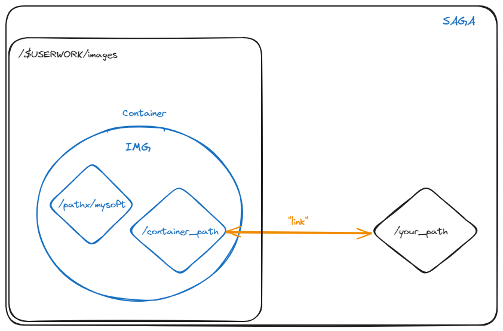

bind paths

[Complete info on click!](https://apptainer.org/docs/user/main/bind_paths_and_mounts.html)

## In a Slurm script

simple syntax

```bash
apptainer exec $IMG  <command>
```

example:

```bash
IMG="/cluster/work/users/evezeyl/images/masurca.sif"
apptainer exec $IMG  masurca -t 4 -i ${R1},${R2} -r ${long_read}  2>&1 | tee masurca_test.log
```

## Build own containers ?

- A recipe for building is written in a file (def file)

! can be time consuming (first search if already existing)

- Recipe “simple” language - compatibility different container systems (docker -> apptainer)

[See: apptainer documentation](https://apptainer.org/docs/user/main/cli/apptainer_build.html)

## Some Advantages / disadvantages of containers

- full reproducibility (OS + software and dependencies)
- No update (both good and bad …if you want latest)
- Takes storage space
- Easy ? …

# Ressources

## Tutorials

- Reproducible Computational Environments Using Containers: Introduction to Docker, A [Carpentries Incubator lesson](https://carpentries-incubator.github.io/docker-introduction/)

## Documentation

- [Apptainer](https://apptainer.org/)
- [Docker](https://docs.docker.com/)
- [Singularity](https://docs.sylabs.io/guides/3.5/user-guide/introduction.html)

[figure not shown]